# Final Project

Coby Eshaghian

2022-05-11

### Introduction

Here, we’re looking at developing a model for predicting home prices in Sacramento. The data we’re using is from a dataset in R, which examines 900+ home sales in Sacramento over a 5-day span. We’ll start off by loading our packages.

NOTE: Data citation: We are pulling this data from the *caret* library, which compiled this data from the Sacramento Bee newspaper

```r
library(ISLR)
library(ISLR2)
library(tidyverse)
library(tidymodels)
library(readr)
library(discrim)
library(tune)
tidymodels_prefer()
```

### About/Loading Data

As mentioned above, the data we’re using is from a 5-day span of sales in the Sacramento area in May 2008. This gives a few benefits. First, the housing market is largely dependent on macroeconomic factors. Hence, by isolating our data to such a short window, we eliminate most macroeconomic factors that would influence our model. On the other hand, it would’ve been nice to have a large data set over multiple years, as we would’ve been able to analyze the effect of time relative to price. However, if that were the case, we would’ve struggled to use a linear regression for data from 2005-2015, given the Great Financial Crisis caused housing prices to form a V-shape (rise, then decline, then recovery), whereas a MLR would’ve succeeded in looking at homes from 2012-2022 (given their steady appreciation in value). In our case, we are in the middle of the decline, where housing in Sacramento bottomed out around Q1 2012.

Thankfully, this data has already been cleaned up, so we don’t have any missing or null data. However, we do have a letter “z” in front of the zip code, which we want to remove.

```r
library(caret)
data("Sacramento")
sac <- Sacramento

head(sac)
```

```
##         city    zip beds baths sqft        type price latitude longitude
## 1 SACRAMENTO z95838    2     1  836 Residential 59222 38.63191 -121.4349
## 2 SACRAMENTO z95823    3     1 1167 Residential 68212 38.47890 -121.4310
## 3 SACRAMENTO z95815    2     1  796 Residential 68880 38.61830 -121.4438
## 4 SACRAMENTO z95815    2     1  852 Residential 69307 38.61684 -121.4391
## 5 SACRAMENTO z95824    2     1  797 Residential 81900 38.51947 -121.4358
## 6 SACRAMENTO z95841    3     1 1122       Condo 89921 38.66260 -121.3278
```

```r
summary(sac)
```

```
##              city          zip           beds           baths
##  SACRAMENTO    :438   z95823 : 61   Min.   :1.000   Min.   :1.000
##  ELK_GROVE     :114   z95828 : 45   1st Qu.:3.000   1st Qu.:2.000
##  ROSEVILLE     : 48   z95758 : 44   Median :3.000   Median :2.000
##  CITRUS_HEIGHTS: 35   z95835 : 37   Mean   :3.276   Mean   :2.053
##  ANTELOPE      : 33   z95838 : 37   3rd Qu.:4.000   3rd Qu.:2.000
##  RANCHO_CORDOVA: 28   z95757 : 36   Max.   :8.000   Max.   :5.000
##  (Other)       :236   (Other):672
##       sqft                type         price           latitude
##  Min.   : 484   Condo       : 53   Min.   : 30000   Min.   :38.24
##  1st Qu.:1167   Multi_Family: 13   1st Qu.:156000   1st Qu.:38.48
##  Median :1470   Residential :866   Median :220000   Median :38.62
##  Mean   :1680                      Mean   :246662   Mean   :38.59
##  3rd Qu.:1954                      3rd Qu.:305000   3rd Qu.:38.69
##  Max.   :4878                      Max.   :884790   Max.   :39.02
##
##    longitude
##  Min.   :-121.6
##  1st Qu.:-121.4
##  Median :-121.4
##  Mean   :-121.4
##  3rd Qu.:-121.3
##  Max.   :-120.6
##
```

```r
nrow(sac)
```

```
## [1] 932
```

Above is a summary of the data, prior to cleanup.

```r
sac$zip<-gsub("z","",as.character(sac$zip))

sac$zip <- as.numeric(as.character(sac$zip))

sac <- subset(sac, select = -c(zip,latitude,longitude))

head(sac)
```

```
##         city beds baths sqft        type price
## 1 SACRAMENTO    2     1  836 Residential 59222
## 2 SACRAMENTO    3     1 1167 Residential 68212
## 3 SACRAMENTO    2     1  796 Residential 68880
## 4 SACRAMENTO    2     1  852 Residential 69307
## 5 SACRAMENTO    2     1  797 Residential 81900
## 6 SACRAMENTO    3     1 1122       Condo 89921
```

We are pulling this data from the *caret* library, which compiled this data from the Sacramento Bee newspaper. Below are the following factors we are examining:

### Data Split

We will also do k-folding to further analyze the accuracy of our model (more on this later)

```r
set.seed(1999)

sac_split <- initial_split(sac, prop = 0.80,
                                strata = price)
sac_train <- training(sac_split)
sac_test <- testing(sac_split)

sac_fold <- vfold_cv(sac_train, strata = type, v = 5)
```

### Exploratory Data Analaysis

First and foremost, I think we should examine our data and see how it’s organized.

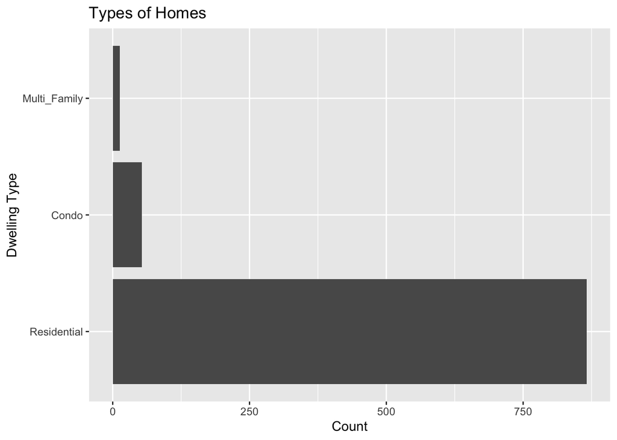

```r
ggplot(sac, aes(x=reorder(type,type,function(x)-length(x)))) +
  geom_bar() +
  labs(
    title = "Types of Homes",
    x = "Dwelling Type",
    y = "Count"
  ) +
  # We want to be able to read labels better
  coord_flip()
```

As we can see, most of the sales we’re examining in this period are residential. This is largely in line with what we’d expect, given the real estate makeup of the Sacramento area.

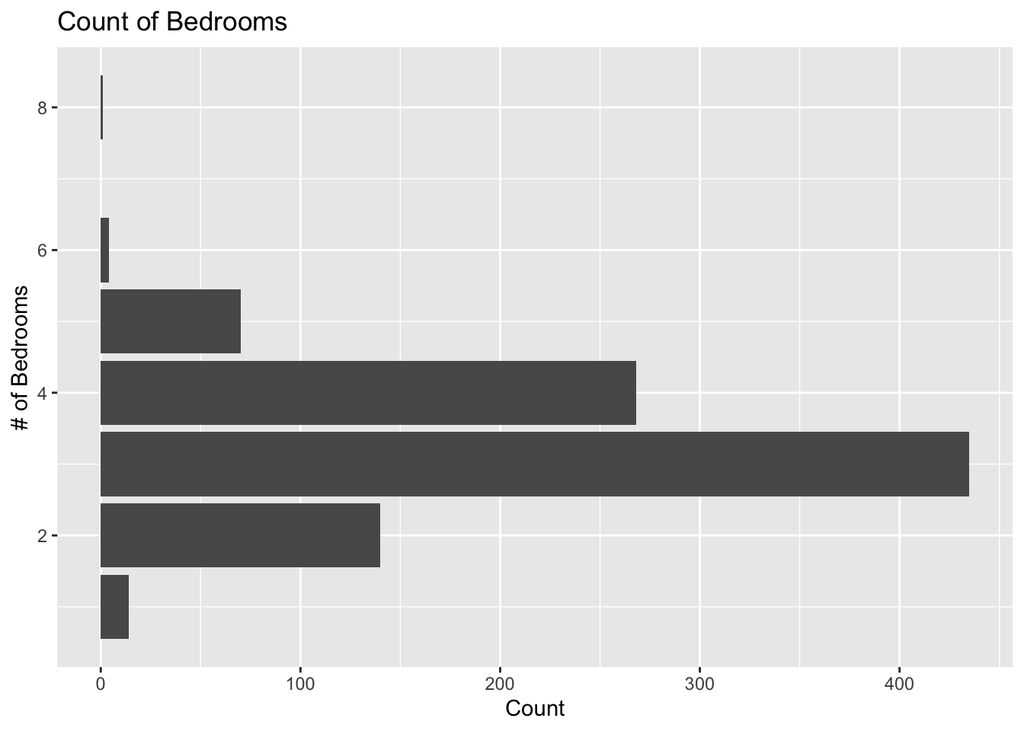

```r
ggplot(sac, aes(beds)) +
  geom_bar() +
  labs(
    title = "Count of Bedrooms",
    x = "# of Bedrooms",
    y = "Count"
  ) +
  # We want to be able to read labels better
  coord_flip()
```

As we can see, most of the dwellings we’re looking at are 3 bedrooms…

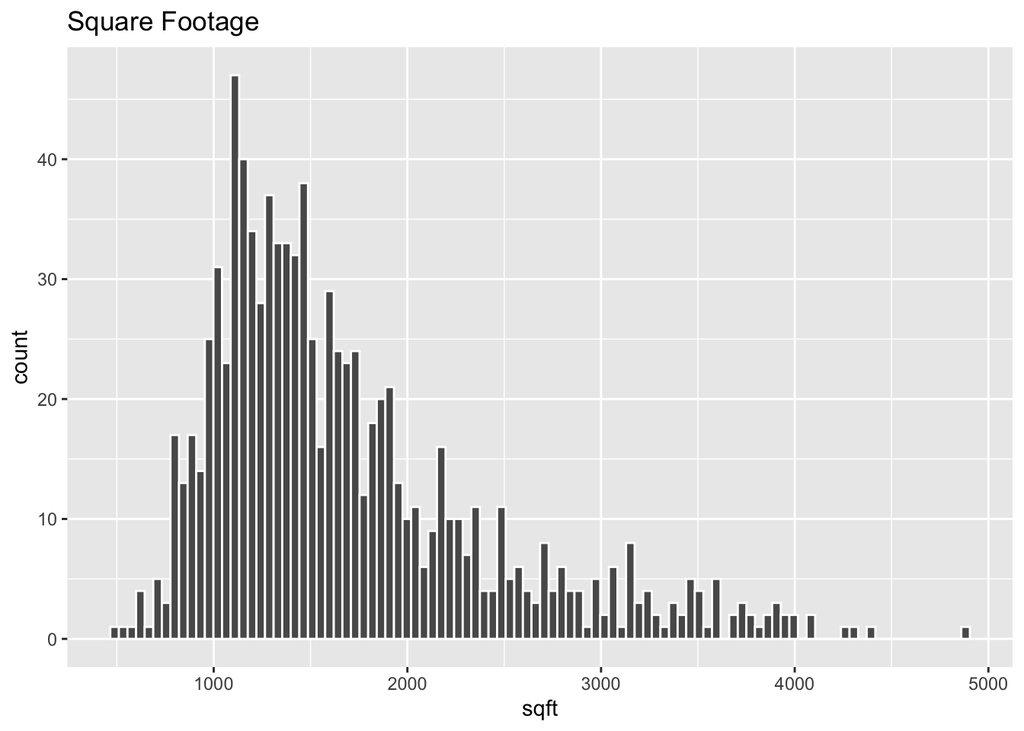

```r
ggplot(sac, aes(sqft)) +
  geom_histogram(bins = 100, color = "white") +
  labs(
    title = "Square Footage"
  )
```

```r
med <- median(sac$sqft)
mn <- mean(sac$sqft)

print(paste("The Mean Is", med))
```

[output not shown]

```r
print(paste("The Median Is", round(mn,0)))
```

[output not shown]

Lastly, we can see that majority of the sales are for homes between one to two thousand square feet. When we do our mean function, it looks like it’s greater than the median, meaning it is positively skewed.

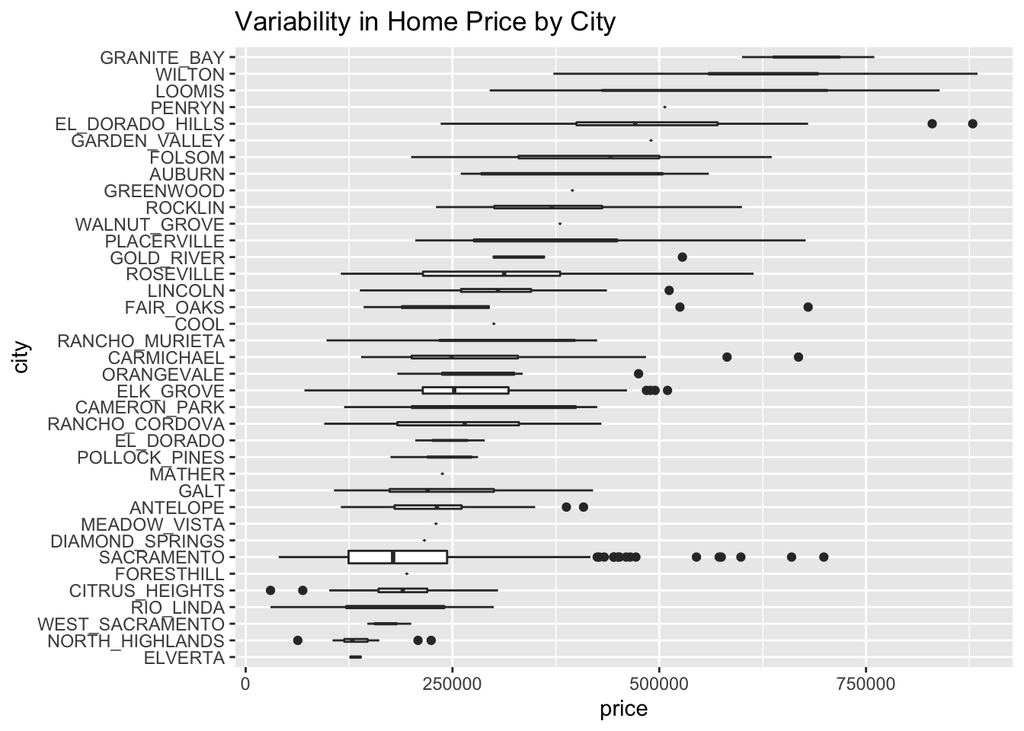

```r
ggplot(sac, aes(reorder(city, price), price)) +
  geom_boxplot(varwidth = TRUE) +
  coord_flip() +
  labs(
    title = "Variability in Home Price by City",
    x = "city"
  )
```

Here, we can see places like Sacramento have much variability in price, whereas North Highlands do not.This may be explained by the higher volume of sales in Sacramento compared to other areas. Let’s see if our plot below confirms…

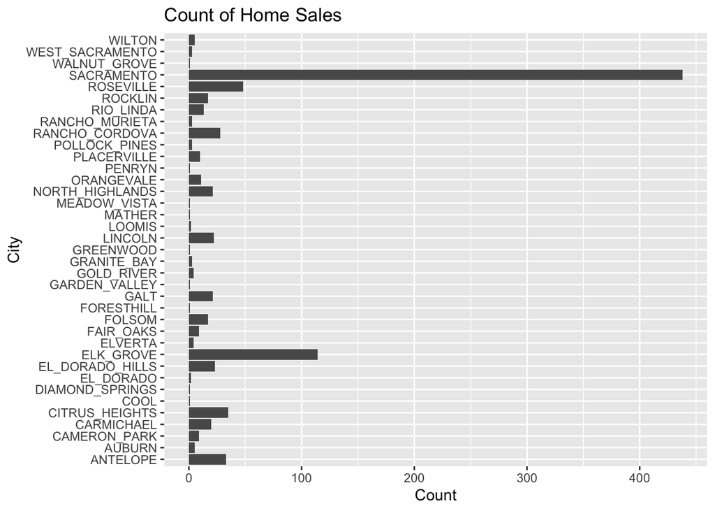

```r
ggplot(sac, aes(city)) +
  geom_bar() +
  labs(
    title = "Count of Home Sales",
    x = "City",
    y = "Count"
  ) +
  # We want to be able to read labels better
  coord_flip()
```

[figure not shown]

```r
sac %>%
  ggplot() +
    geom_boxplot(mapping=aes(x = city, y = sqft, fill = type))
```

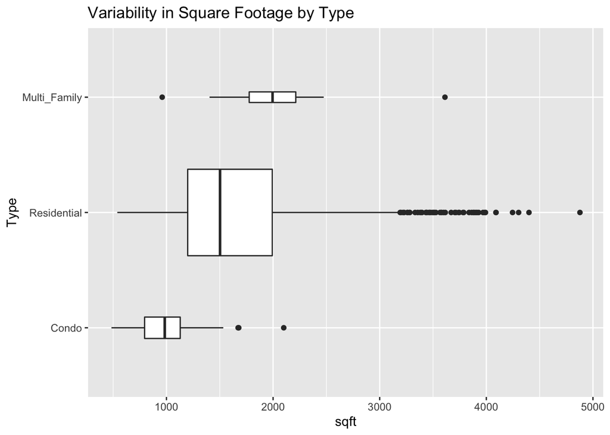

```r
ggplot(sac, aes(reorder(type, sqft), sqft)) +
  geom_boxplot(varwidth = TRUE) +
  coord_flip() +
  labs(
    title = "Variability in Square Footage by Type",
    x = "Type"
  )
```

Here’s some analysis on the variables themselves…

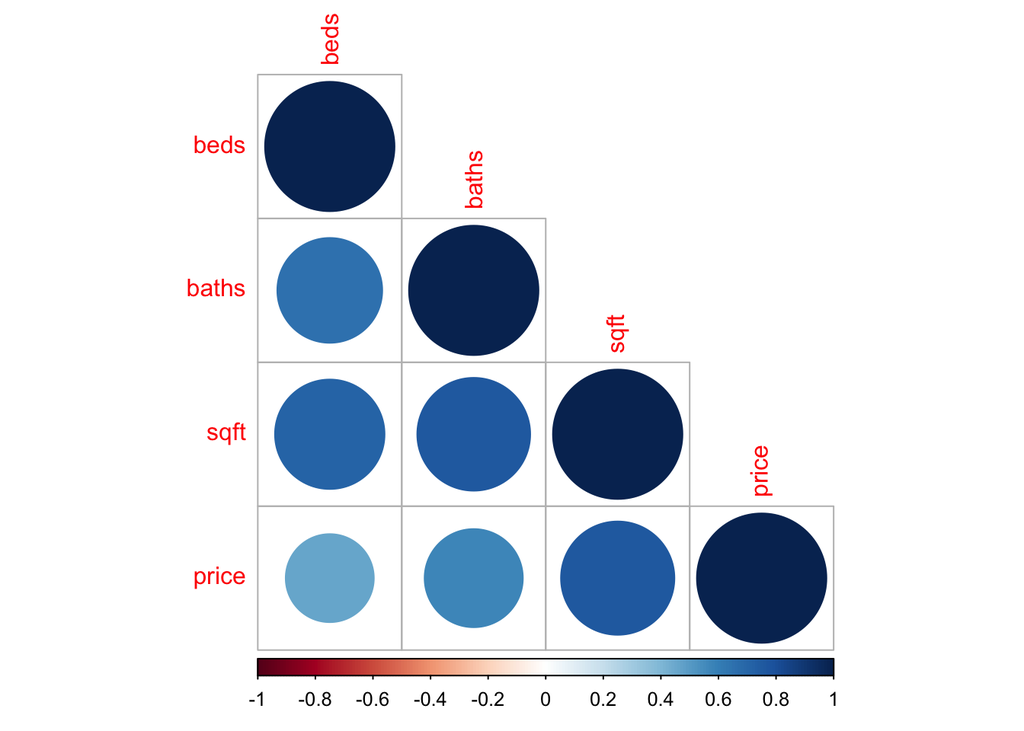

```r
library(corrplot)
sac %>%
  select(is.numeric) %>%
  cor() %>%
  corrplot(type = "lower")
```

As expected, we’d expect all these things to be positively correlated, such as more sqft = higher price = more beds = more baths. However, I’m surprised this isn’t a stronger relationship between beds and price. Just a personal observation, that may not surprise someone else.

### Analysis

First and foremost, let’s establish what we’re trying to predict. We will do two experiments with two hypothesis. First, let’s build a model to with price as our response variable, and the other factors as our predictor. We will then analyze which model fits best, as well as test its accuracy against our training data.

```r
sacrec <- recipe(price ~ ., data = sac_train) %>%
  step_dummy(all_nominal_predictors()) %>%
  step_center(all_numeric_predictors()) %>%
  step_scale((all_numeric_predictors()))
```

```r
lm_model <- linear_reg() %>%
  set_engine("lm")
```

```r
lm_wflow <- workflow() %>%
  add_recipe(sacrec) %>%
  add_model(lm_model)

sac_fit <- fit(lm_wflow, sac_train)
```

```r
multi_metric <- metric_set(rmse, rsq, mae)
price_predict <- predict(sac_fit, sac_train) %>%
  bind_cols(sac_train %>% select(price))

multi_metric(price_predict, truth = price, estimate = .pred)
```

```
## # A tibble: 3 × 3
##   .metric .estimator .estimate
##   <chr>   <chr>          <dbl>
## 1 rmse    standard   69114.
## 2 rsq     standard       0.725
## 3 mae     standard   49983.
```

As we can see, we have a RSQ of roughly 73%, which is pretty decent. In other words, 73% of the variance is explained by our variables. This is a figure I’m pretty satisfied with. However, we can look at some other diagnostics in our model…

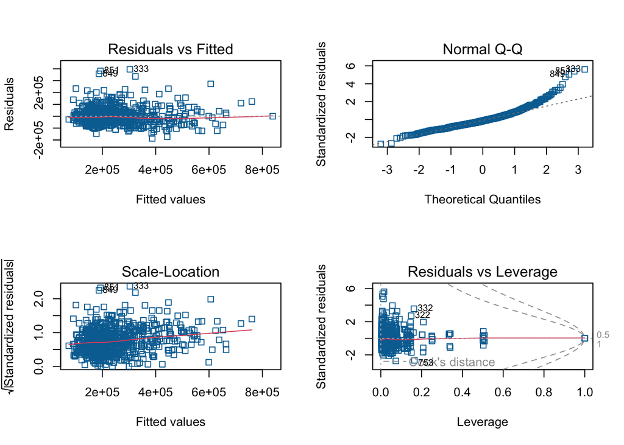

```r
lm_fit2 <- lm_model %>%
          fit(price ~ ., data = sac_train)

par(mfrow=c(2,2)) # plot all 4 plots in one

plot(lm_fit2$fit,
     pch = 0,
     col = '#006EA1')
```

Now, let’s run some classification models. The first one we’re going to run is going to try to predict the type of home

```r
library(MASS)
library(discrim)

sacrec2 <- recipe(type~., data = sac_train) %>%
  step_dummy(all_nominal_predictors()) %>%
  step_center(all_numeric_predictors()) %>%
  step_scale((all_numeric_predictors()))

log_model <- logistic_reg() %>%
  set_mode("classification") %>%
  set_engine("glm")

log_wkflow <- workflow() %>%
  add_model(log_model) %>%
  add_recipe(sacrec2)

lda_mod <- discrim_linear() %>%
  set_mode("classification") %>%
  set_engine("MASS")

lda_wkflow <- workflow() %>%
  add_model(lda_mod) %>%
  add_recipe(sacrec2)

qda_mod <- discrim_quad() %>%
  set_mode("classification") %>%
  set_engine("MASS")

qda_wkflow <- workflow() %>%
  add_model(qda_mod) %>%
  add_recipe(sacrec2)
```

```r
control <- control_resamples(save_pred = TRUE)

log_fit <- fit_resamples(log_wkflow, sac_fold)
```

[output not shown]

[output not shown]

[output not shown]

[output not shown]

[output not shown]

[output not shown]

```r
lda_fit <- fit_resamples(lda_wkflow, sac_fold)
```

[output not shown]

[output not shown]

[output not shown]

[output not shown]

```r
qda_fit <- fit_resamples(qda_wkflow, resamples = sac_fold)
```

[output not shown]

[output not shown]

[output not shown]

[output not shown]

[output not shown]

```r
sacres <- sum(sac$city == 'SACRAMENTO'  & sac$type=='Residential', na.rm=TRUE)
sacres_portion <- sacres/nrow(sac)
sacres_portion
```

```
## [1] 0.4313305
```

A staggering 43% of our data is simply residential homes in Sacramento. This explains why we are having trouble building classifaction models with such limited data on other classes.

Going back to what we can work on…

```r
sacrec3 <- recipe(sqft ~ ., data = sac_train) %>%
  step_dummy(all_nominal_predictors()) %>%
  step_center(all_numeric_predictors()) %>%
  step_scale((all_numeric_predictors()))

lm_wflow2 <- workflow() %>%
  add_recipe(sacrec3) %>%
  add_model(lm_model)

sac_fit2 <- fit(lm_wflow2, sac_train)
```

```r
multi_metric <- metric_set(rmse, rsq, mae)
sqft_predict <- predict(sac_fit2, sac_train) %>%
  bind_cols(sac_train %>% select(sqft))

multi_metric(sqft_predict, truth = sqft, estimate = .pred)
```

```
## # A tibble: 3 × 3
##   .metric .estimator .estimate
##   <chr>   <chr>          <dbl>
## 1 rmse    standard     302.
## 2 rsq     standard       0.830
## 3 mae     standard     224.
```

Here, we get an even higher rsq of 83%. As I did for the other plot, here’s some visuals…

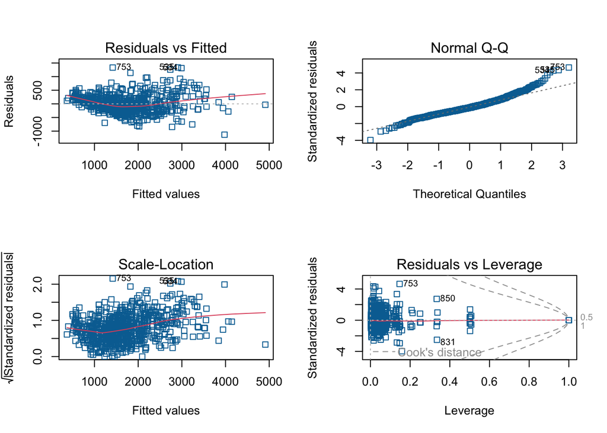

```r
lm_fit3 <- lm_model %>%
          fit(sqft ~ ., data = sac_train)

par(mfrow=c(2,2)) # plot all 4 plots in one

plot(lm_fit3$fit,
     pch = 0,
     col = '#006EA1')
```

Lastly, we can attempt to build a classification model, based on the bedroom size. Since it’s discrete and there’s a wide variety, we can turn it into a factor and attempt to run classification models, in a last ditch effort.

```r
sac2 <- sac

sac2$beds=as.factor(sac2$beds)
sac2$baths=as.factor(sac2$baths)
```

Here, we turned both beds and baths into factors. Now, we will reseed and split the data.

```r
set.seed(2002)

sac_split2 <- initial_split(sac2, prop = 0.80,
                                strata = type)
sac_train2 <- training(sac_split2)
sac_test2 <- testing(sac_split2)

sac_fold2 <- vfold_cv(sac_train2, strata = type, v = 5)
```

Now, we can begin our entire process from earlier, all over again…

```r
sacrec4 <- recipe(beds~., data = sac_train2) %>%
  step_dummy(all_nominal_predictors()) %>%
  step_center(all_numeric_predictors()) %>%
  step_scale((all_numeric_predictors()))

log_model <- logistic_reg() %>%
  set_mode("classification") %>%
  set_engine("glm")

log_wkflow2 <- workflow() %>%
  add_model(log_model) %>%
  add_recipe(sacrec4)

lda_mod <- discrim_linear() %>%
  set_mode("classification") %>%
  set_engine("MASS")

lda_wkflow2 <- workflow() %>%
  add_model(lda_mod) %>%
  add_recipe(sacrec4)

qda_mod <- discrim_quad() %>%
  set_mode("classification") %>%
  set_engine("MASS")

qda_wkflow2 <- workflow() %>%
  add_model(qda_mod) %>%
  add_recipe(sacrec4)
```

```r
control <- control_resamples(save_pred = TRUE)

log_fit <- fit_resamples(log_wkflow2, sac_fold)
```

[output not shown]

[output not shown]

[output not shown]

[output not shown]

[output not shown]

[output not shown]

[output not shown]

[output not shown]

[output not shown]

[output not shown]

```r
lda_fit <- fit_resamples(lda_wkflow2, sac_fold, control = control)
```

[output not shown]

[output not shown]

[output not shown]

[output not shown]

[output not shown]

[output not shown]

[output not shown]

[output not shown]

[output not shown]

[output not shown]

```r
qda_fit <- fit_resamples(qda_wkflow2, resamples = sac_fold2)
```

[output not shown]

[output not shown]

[output not shown]

[output not shown]

[output not shown]

We encounter a similar situation here, where our data isn’t spread enough for a qda model. We see all our models failed. Hence, we can just try more lin. regression…

```r
sacrec5 <- recipe(beds~., data = sac_train) %>%
  step_dummy(all_nominal_predictors()) %>%
  step_center(all_numeric_predictors()) %>%
  step_scale((all_numeric_predictors()))
```

```r
lm_wflow3 <- workflow() %>%
  add_recipe(sacrec5) %>%
  add_model(lm_model)

sac_fit3 <- fit(lm_wflow3, sac_train)

multi_metric <- metric_set(rmse, rsq, mae)
beds_predict <- predict(sac_fit3, sac_train) %>%
  bind_cols(sac_train %>% select(beds))

multi_metric(beds_predict, truth = beds, estimate = .pred)
```

```
## # A tibble: 3 × 3
##   .metric .estimator .estimate
##   <chr>   <chr>          <dbl>
## 1 rmse    standard       0.508
## 2 rsq     standard       0.654
## 3 mae     standard       0.398
```

Here, we see our model performed somewhat poorly compared to our other regression models in predicting sqft and price. Nevertheless, 65% is something to be satisfied with.

Similar to my above LM’s, below are some more diagnostics…

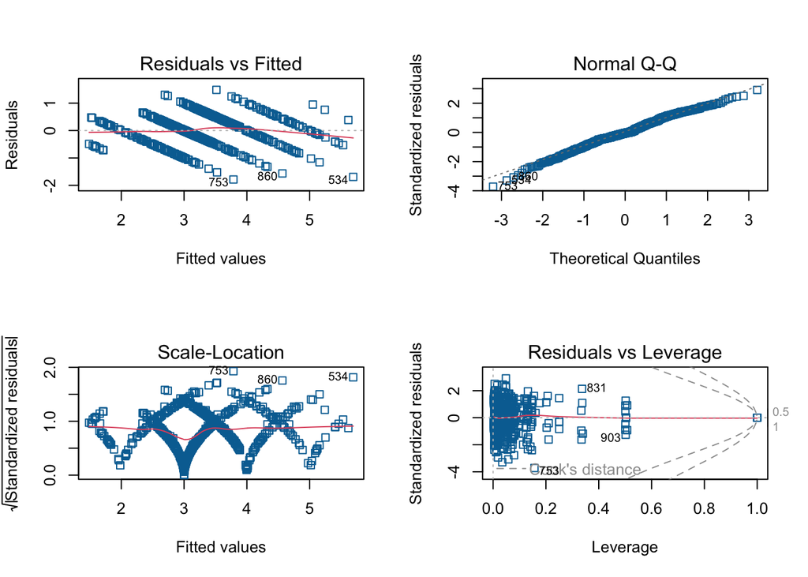

```r
lm_fit4 <- lm_model %>%
          fit(beds ~ ., data = sac_train)

par(mfrow=c(2,2)) # plot all 4 plots in one

plot(lm_fit4$fit,
     pch = 0,
     col = '#006EA1')
```